# 近江貝塚研第324回例会「陽明文庫所蔵史料と松尾大社所蔵史料の料紙における構成物の変化」関連データ

渋谷綾子（東京大学史料編纂所）

```r
# パッケージの読み込み
library(ggplot2)
library(readr)
library(tidyverse)
library(knitr)
library(rmarkdown)
library(revealjs)
library(scales)
library(reshape2)
library(ggfortify)
```

# 料紙面積と構成物の相関分析（無相関検定）

## 松尾大社社蔵史料

帰無仮説H₀：母相関は0である「調査史料では料紙面積と構成物に相関がない」  
対立仮説H₁：母相関は0ではない「調査史料では料紙面積と構成物に相関がある」

```r
tbs1 <- read_csv("matsunoo-square.csv")  # CSVファイルの読み取り
tbs1 # 読み込んだデータ
```

```
# A tibble: 239 x 4
   目録番号 紙素材 料紙面積 構成物合計
      <dbl> <chr>     <dbl>      <dbl>
 1        1 コウゾ    1546.         15
 2        1 コウゾ    1546.         20
 3        1 コウゾ    1546.          6
 4        2 コウゾ    2014.         90
 5        2 コウゾ    2014.         43
 6        2 コウゾ    2014.         40
 7        2 コウゾ    2014.         75
 8        2 コウゾ    2014.         43
 9        2 コウゾ    2014.         87
10        2 コウゾ    2014.         72
# ... with 229 more rows
```

```r
# 構成物の種類を実数型に変換
tbs2 <-
  tbs1 %>%
  filter(紙素材 %in% "コウゾ") %>%　　　 # コウゾだけを選択
  mutate(
    面積 = as.numeric(料紙面積), 　　　　# 料紙面積を実数に変換
    構成物合計 = as.numeric(構成物合計)) # 構成物合計を実数に変換

# 料紙面積と構成物合計の相関係数と無相関検定
attach(tbs2)

cor(構成物合計,料紙面積, method="spearman") 　　 # スピアマンの相関係数
```

```
[1] 0.4178254
```

```r
cor.test(構成物合計,料紙面積, method="pearson")  # 無相関かどうかの検定
```

```
    Pearson's product-moment correlation

data:  構成物合計 and 料紙面積
t = 4.5859, df = 235, p-value = 7.352e-06
alternative hypothesis: true correlation is not equal to 0
95 percent confidence interval:
 0.1652044 0.3994431
sample estimates:
      cor
0.2866011
```

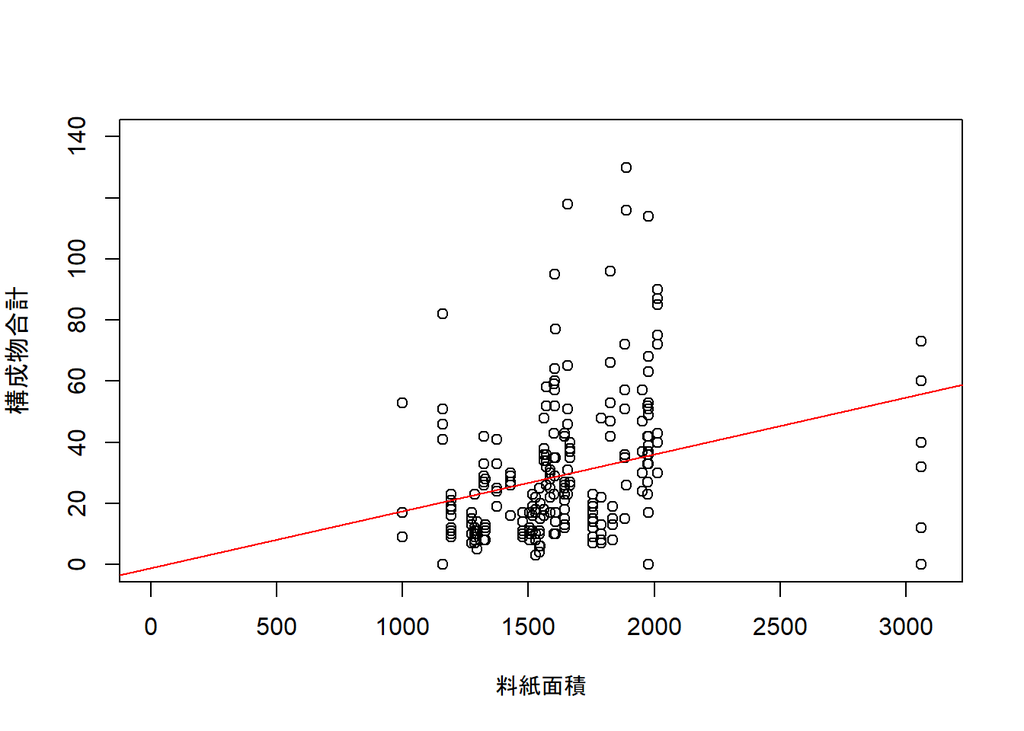

```r
plot(料紙面積,構成物合計, xlim=c(0,3100), ylim=c(0,140)) # xlimとylimで範囲を指定
abline(lm(構成物合計~料紙面積), col="red") # 回帰直線を入れる→Fig1として保存
```

## 陽明文庫所蔵史料

帰無仮説H₀：母相関は0である「調査史料では料紙面積と構成物に相関がない」  
対立仮説H₁：母相関は0ではない「調査史料では料紙面積と構成物に相関がある」

```r
tbs3 <- read_csv("yomei-square.csv")  # CSVファイルの読み取り
tbs3 # 読み込んだデータ
```

```
# A tibble: 320 x 4
   目録番号 紙素材 料紙面積 構成物合計
      <dbl> <chr>     <dbl>      <dbl>
 1        1 コウゾ    1546.         15
 2        1 コウゾ    1546.         20
 3        1 コウゾ    1546.          6
 4        2 コウゾ    2014.         90
 5        2 コウゾ    2014.         43
 6        2 コウゾ    2014.         40
 7        2 コウゾ    2014.         75
 8        2 コウゾ    2014.         43
 9        2 コウゾ    2014.         87
10        2 コウゾ    2014.         72
# ... with 310 more rows
```

```r
# 構成物の種類を実数型に変換
tbs4 <-
  tbs3 %>%
  filter(紙素材 %in% "コウゾ") %>%　　　 # コウゾだけを選択
  mutate(
    面積 = as.numeric(料紙面積), 　　　　# 料紙面積を実数に変換
    構成物合計 = as.numeric(構成物合計)) # 構成物合計を実数に変換

# 料紙面積と構成物合計の相関係数と無相関検定
attach(tbs4)

cor(構成物合計,料紙面積, method="spearman") 　　 # スピアマンの相関係数
```

```
[1] -0.01682827
```

```r
cor.test(構成物合計,料紙面積, method="pearson")  # 無相関かどうかの検定
```

```
    Pearson's product-moment correlation

data:  構成物合計 and 料紙面積
t = -1.7943, df = 316, p-value = 0.07371
alternative hypothesis: true correlation is not equal to 0
95 percent confidence interval:
 -0.208115457  0.009661945
sample estimates:
       cor
-0.1004295
```

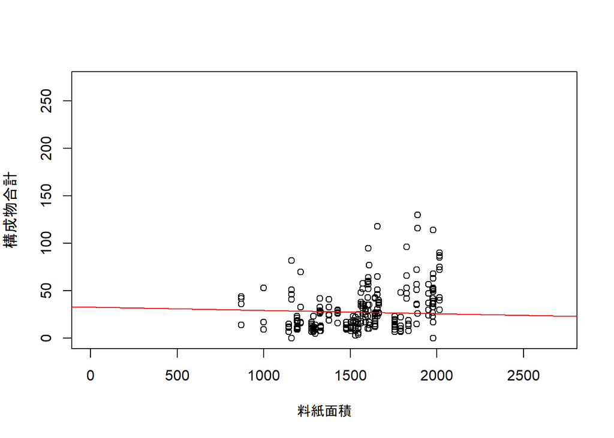

```r
plot(料紙面積,構成物合計, xlim=c(0,2700), ylim=c(0,270)) # xlimとylimで範囲を指定
abline(lm(構成物合計~料紙面積), col="red") # 回帰直線を入れる→Fig2として保存
```

# 料紙構成物に対する主成分分析

## 松尾大社社蔵史料

```r
tbs5 <- read_csv("matsunoo-compo.csv")  # CSVファイルの読み取り
tbs5 # 読み込んだデータ
```

```
# A tibble: 63 x 7
   目録番号 紙素材 デンプン粒  鉱物 細胞組織  繊維  ほか
      <dbl> <chr>       <dbl> <dbl>    <dbl> <dbl> <dbl>
 1        1 コウゾ          0     0        0     0    41
 2        2 コウゾ          0     0      497     6    62
 3        3 コウゾ          2     6      263     0     0
 4        4 コウゾ          0     1      236     5     0
 5        5 コウゾ          0     0      207     6     0
 6        6 コウゾ          0     0      207     6     0
 7        7 コウゾ          0     0      348     9     0
 8        8 コウゾ          0     0      194     9     0
 9        9 コウゾ          0     0      326     8     0
10       10 宿紙           20     0       35     4     0
# ... with 53 more rows
```

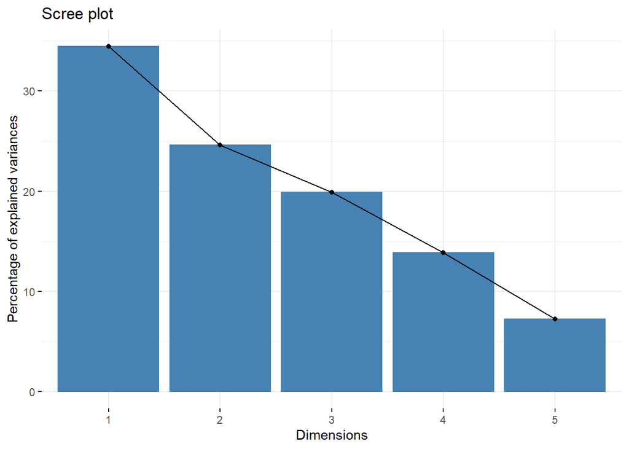

```r
# 構成物の種類を実数型に変換
tbs6 <-
  tbs5 %>%
  filter(紙素材 %in% "コウゾ") %>%　　　 # コウゾだけを選択
  select(デンプン粒,鉱物,細胞組織,繊維,ほか) %>%
  mutate(
    デンプン粒 = as.numeric(デンプン粒), # デンプン粒を実数に変換
    鉱物 = as.numeric(鉱物),　　　　　　 # 鉱物を実数に変換
    細胞組織 = as.numeric(細胞組織),　　 # 細胞組織を実数に変換
    繊維 = as.numeric(繊維),　　　　　　 # 繊維を実数に変換
    ほか = as.numeric(ほか))　　　　　　 # ほか（他の物質）を実数に変換

# 主成分分析を行うパッケージFactoMineRを読み込み，主成分分析を実行
library(FactoMineR)
# 主成分分析を実行
res.pca <-
  PCA(tbs6,graph = FALSE)

# 多変量解析の可視化に特化したfactoextraパッケージ
library(factoextra)
# 各主成分の寄与率を描画
fviz_screeplot(res.pca)
```

```r
ggsave(file = "Fig3.png", width = 6, height = 6, dpi = 300) # ファイルの保存

# 主成分分析の概要を表示
summary(res.pca)
```

```
Call:
PCA(X = tbs6, graph = FALSE)


Eigenvalues
                       Dim.1   Dim.2   Dim.3   Dim.4   Dim.5
Variance               1.724   1.229   0.994   0.692   0.361
% of var.             34.480  24.580  19.880  13.848   7.211
Cumulative % of var.  34.480  59.060  78.940  92.789 100.000

Individuals (the 10 first)
          Dist    Dim.1    ctr   cos2    Dim.2    ctr   cos2    Dim.3    ctr
1     |  3.149 | -1.780  3.170  0.320 |  0.052  0.004  0.000 | -2.021  7.081
2     |  5.492 |  1.109  1.230  0.041 |  3.626 18.443  0.436 | -2.647 12.156
3     |  2.592 | -0.358  0.128  0.019 |  0.687  0.663  0.070 |  2.121  7.802
4     |  1.233 |  1.144  1.310  0.862 |  0.206  0.060  0.028 |  0.383  0.255
5     |  1.350 |  1.331  1.773  0.972 |  0.008  0.000  0.000 |  0.018  0.001
6     |  1.350 |  1.331  1.773  0.972 |  0.008  0.000  0.000 |  0.018  0.001
7     |  2.708 |  2.554  6.522  0.889 |  0.892  1.117  0.109 |  0.114  0.023
8     |  2.073 |  1.868  3.489  0.812 |  0.129  0.023  0.004 |  0.003  0.000
9     |  2.374 |  2.258  5.097  0.904 |  0.721  0.730  0.092 |  0.100  0.017
10    |  0.684 |  0.160  0.026  0.055 | -0.572  0.458  0.698 |  0.292  0.148
        cos2
1      0.412 |
2      0.232 |
3      0.670 |
4      0.097 |
5      0.000 |
6      0.000 |
7      0.002 |
8      0.000 |
9      0.002 |
10     0.182 |

Variables
              Dim.1    ctr   cos2    Dim.2    ctr   cos2    Dim.3    ctr   cos2
デンプン粒 | -0.466 12.587  0.217 |  0.664 35.858  0.441 | -0.007  0.004  0.000
鉱物       | -0.364  7.696  0.133 |  0.306  7.614  0.094 |  0.801 64.597  0.642
細胞組織   |  0.670 26.035  0.449 |  0.629 32.212  0.396 |  0.082  0.683  0.007
繊維       |  0.872 44.058  0.760 |  0.231  4.329  0.053 | -0.006  0.004  0.000
ほか       | -0.407  9.624  0.166 |  0.496 19.988  0.246 | -0.587 34.711  0.345

デンプン粒 |
鉱物       |
細胞組織   |
繊維       |
ほか       |
```

```r
res.pca$eig %>%
  kable()
```

|  | eigenvalue | percentage of variance | cumulative percentage of variance |
| --- | --- | --- | --- |
| comp 1 | 1.7240043 | 34.480085 | 34.48009 |
| comp 2 | 1.2290034 | 24.580068 | 59.06015 |
| comp 3 | 0.9940092 | 19.880184 | 78.94034 |
| comp 4 | 0.6924212 | 13.848425 | 92.78876 |
| comp 5 | 0.3605619 | 7.211238 | 100.00000 |

```r
# eigenvaluesは主成分の分散，percentage of variancevは寄与率，cumulative percentage of varianceが累積寄与率を示す
# スクリープロットを作成するfviz_screeplot()は，自動的にpercentage of varianceをy値に出力する
```

### 主成分に対する各変数の寄与率を出図

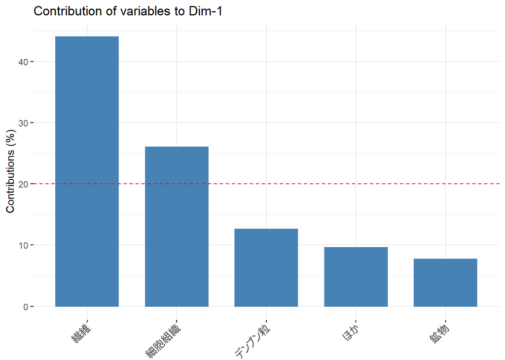

```r
fviz_contrib(res.pca,
             choice = "var",  # 変数ごとの寄与率(ctr)
             axes = 1,        # 主成分1を指定（変更すると各主成分が指定できる）
             top = 10)　      # 表示する変数の数を指定
```

```r
ggsave(file = "Fig4.png", width = 6, height = 6, dpi = 300) # ファイルの保存

res.pca$var$contrib %>%
  kable() # y軸に指定されている"var"でres.pcaオブジェクトの要素であるres.pca$varを引数に指定
```

|  | Dim.1 | Dim.2 | Dim.3 | Dim.4 | Dim.5 |
| --- | --- | --- | --- | --- | --- |
| デンプン粒 | 12.587254 | 35.857544 | 0.0043032 | 47.1251195 | 4.425780 |
| 鉱物 | 7.695513 | 7.613503 | 64.5973511 | 17.8404525 | 2.253181 |
| 細胞組織 | 26.034852 | 32.212331 | 0.6832773 | 0.1188592 | 40.950680 |
| 繊維 | 44.057997 | 4.328647 | 0.0042373 | 0.3357157 | 51.273403 |
| ほか | 9.624384 | 19.987975 | 34.7108311 | 34.5798530 | 1.096956 |

第1主成分は繊維，細胞組織が高い寄与率を占めることから，第1主成分は「素材由来」と要約できる。

### 主成分得点の散布図を出力

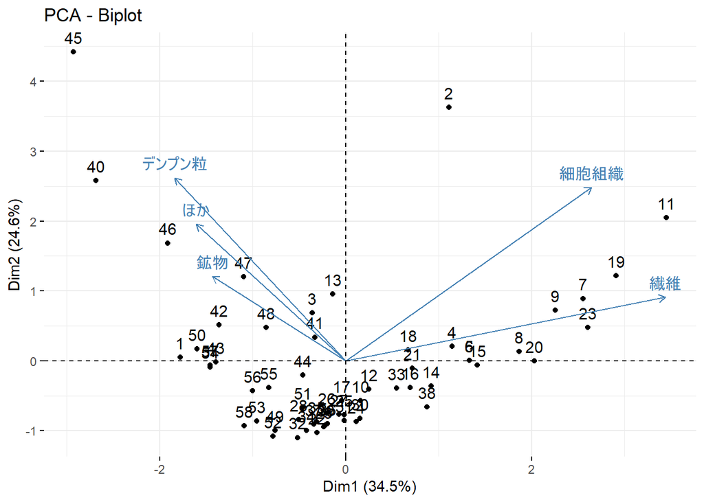

```r
fviz_pca_biplot(res.pca) # 主成分1と2を表示，axes = C(○,○))で別の主成分を表示可能
```

```r
ggsave(file = "Fig5.png", width = 6, height = 6, dpi = 300) # ファイルの保存
```

細胞組織の断片と繊維は同じ意味をもつ変数，すなわち素材由来の構成物であり，デンプン粒と鉱物，ほか（他の物質）は填料を示している。

## 陽明文庫所蔵史料

```r
tbs7 <- read_csv("yomei-compo.csv")  # CSVファイルの読み取り
tbs7 # 読み込んだデータ
```

```
# A tibble: 89 x 7
   史料番号 紙素材 デンプン粒  鉱物 細胞組織  繊維  ほか
   <chr>    <chr>       <dbl> <dbl>    <dbl> <dbl> <dbl>
 1 11-391   コウゾ         20     3       97     1    28
 2 11-392   コウゾ          0     0       62     0     0
 3 11-393   コウゾ          5     1      119     0     0
 4 11-394   コウゾ          0     0       74     0    10
 5 11-396   コウゾ          0     1      108     0     0
 6 11-397   コウゾ          0     1       58     1     0
 7 11-398   コウゾ          0     0       91     0     0
 8 11-399   コウゾ          0     0       48     0    10
 9 11-400   コウゾ         81     4       95     0     0
10 11-401   コウゾ          0     0       19     0     5
# ... with 79 more rows
```

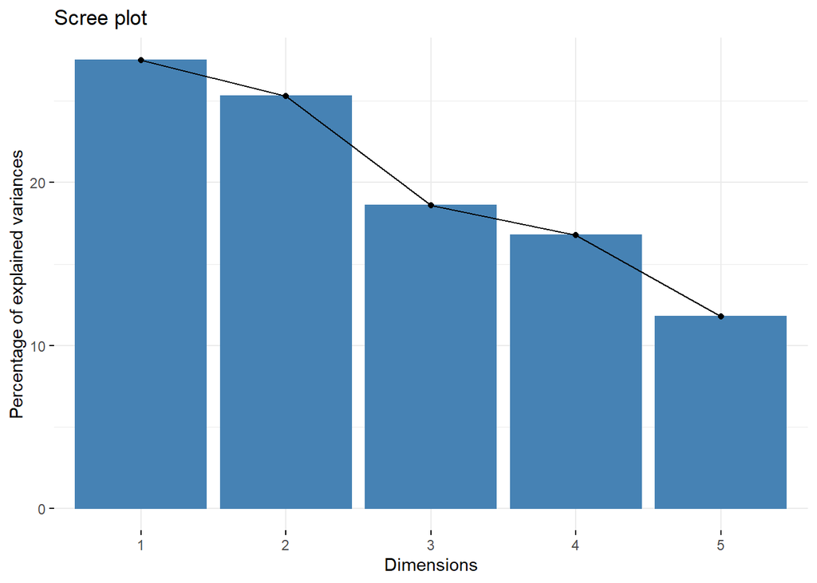

```r
# 構成物の種類を実数型に変換
tbs8 <-
  tbs7 %>%
  filter(紙素材 %in% "コウゾ") %>%　　　 # コウゾだけを選択
  select(デンプン粒,鉱物,細胞組織,繊維,ほか) %>%
  mutate(
    デンプン粒 = as.numeric(デンプン粒), # デンプン粒を実数に変換
    鉱物 = as.numeric(鉱物),　　　　　　 # 鉱物を実数に変換
    細胞組織 = as.numeric(細胞組織),　　 # 細胞組織を実数に変換
    繊維 = as.numeric(繊維),　　　　　　 # 繊維を実数に変換
    ほか = as.numeric(ほか))　　　　　　 # ほか（他の物質）を実数に変換

# 主成分分析を行うパッケージFactoMineRを読み込み，主成分分析を実行
library(FactoMineR)
# 主成分分析を実行
res.pca <-
  PCA(tbs8,graph = FALSE)

# 多変量解析の可視化に特化したfactoextraパッケージ
library(factoextra)
# 各主成分の寄与率を描画
fviz_screeplot(res.pca)
```

```r
ggsave(file = "Fig6.png", width = 6, height = 6, dpi = 300) # ファイルの保存

# 主成分分析の概要を表示
summary(res.pca)
```

```
Call:
PCA(X = tbs8, graph = FALSE)


Eigenvalues
                       Dim.1   Dim.2   Dim.3   Dim.4   Dim.5
Variance               1.377   1.266   0.930   0.838   0.589
% of var.             27.532  25.325  18.609  16.760  11.774
Cumulative % of var.  27.532  52.857  71.466  88.226 100.000

Individuals (the 10 first)
          Dist    Dim.1    ctr   cos2    Dim.2    ctr   cos2    Dim.3    ctr
1     |  3.623 |  2.731  6.374  0.568 |  1.492  2.069  0.170 |  1.497  2.835
2     |  0.903 | -0.761  0.495  0.710 | -0.239  0.053  0.070 | -0.400  0.202
3     |  1.461 | -0.634  0.344  0.188 |  1.145  1.218  0.614 |  0.638  0.514
4     |  0.895 | -0.384  0.126  0.184 | -0.326  0.099  0.133 |  0.149  0.028
5     |  1.298 | -0.735  0.462  0.321 |  0.912  0.773  0.494 |  0.515  0.335
6     |  1.294 |  0.302  0.078  0.055 | -0.203  0.038  0.025 |  0.137  0.024
7     |  1.036 | -0.965  0.796  0.867 |  0.048  0.002  0.002 |  0.155  0.030
8     |  1.015 | -0.201  0.035  0.039 | -0.583  0.316  0.330 | -0.348  0.153
9     |  6.146 |  3.290  9.250  0.287 |  4.873 22.063  0.629 | -1.045  1.380
10    |  1.419 | -0.228  0.045  0.026 | -0.767  0.547  0.292 | -1.063  1.428
        cos2
1      0.171 |
2      0.196 |
3      0.190 |
4      0.028 |
5      0.157 |
6      0.011 |
7      0.022 |
8      0.118 |
9      0.029 |
10     0.561 |

Variables
              Dim.1    ctr   cos2    Dim.2    ctr   cos2    Dim.3    ctr   cos2
デンプン粒 |  0.650 30.655  0.422 |  0.432 14.755  0.187 | -0.262  7.365  0.069
鉱物       |  0.396 11.373  0.157 |  0.756 45.131  0.571 |  0.032  0.112  0.001
細胞組織   | -0.345  8.627  0.119 |  0.466 17.117  0.217 |  0.771 63.929  0.595
繊維       |  0.541 21.281  0.293 | -0.470 17.409  0.220 |  0.375 15.128  0.141
ほか       |  0.622 28.064  0.386 | -0.266  5.588  0.071 |  0.354 13.465  0.125

デンプン粒 |
鉱物       |
細胞組織   |
繊維       |
ほか       |
```

```r
res.pca$eig %>%
  kable()
```

|  | eigenvalue | percentage of variance | cumulative percentage of variance |
| --- | --- | --- | --- |
| comp 1 | 1.3766096 | 27.53219 | 27.53219 |
| comp 2 | 1.2662437 | 25.32487 | 52.85707 |
| comp 3 | 0.9304291 | 18.60858 | 71.46565 |
| comp 4 | 0.8380248 | 16.76050 | 88.22614 |
| comp 5 | 0.5886928 | 11.77386 | 100.00000 |

```r
# eigenvaluesは主成分の分散，percentage of variancevは寄与率，cumulative percentage of varianceが累積寄与率を示す
# スクリープロットを作成するfviz_screeplot()は，自動的にpercentage of varianceをy値に出力する
```

### 主成分に対する各変数の寄与率を出図

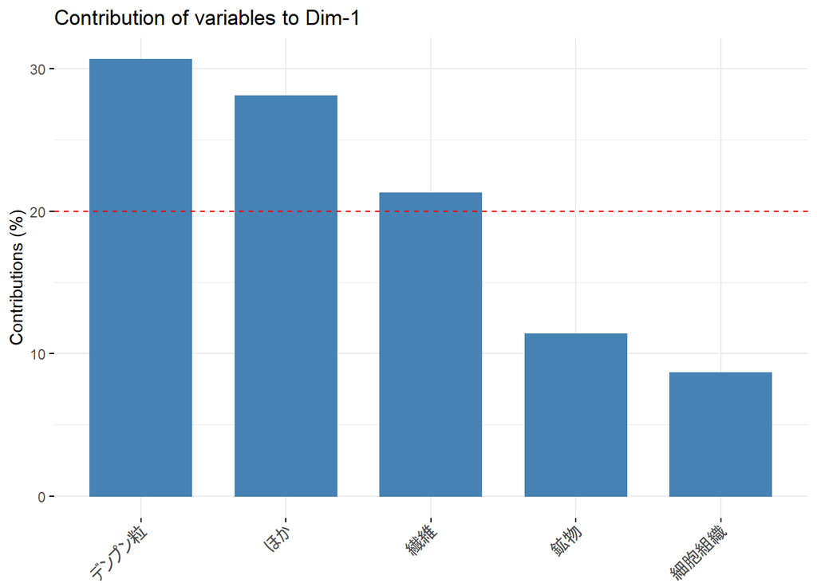

```r
fviz_contrib(res.pca,
             choice = "var",  # 変数ごとの寄与率(ctr)
             axes = 1,        # 主成分1を指定（変更すると各主成分が指定できる）
             top = 10)　      # 表示する変数の数を指定
```

```r
ggsave(file = "Fig7.png", width = 6, height = 6, dpi = 300) # ファイルの保存

res.pca$var$contrib %>%
  kable() # y軸に指定されている"var"でres.pcaオブジェクトの要素であるres.pca$varを引数に指定
```

|  | Dim.1 | Dim.2 | Dim.3 | Dim.4 | Dim.5 |
| --- | --- | --- | --- | --- | --- |
| デンプン粒 | 30.654628 | 14.755364 | 7.3649657 | 17.899973 | 29.325069 |
| 鉱物 | 11.372538 | 45.130749 | 0.1119077 | 6.230577 | 37.154228 |
| 細胞組織 | 8.627449 | 17.117302 | 63.9292627 | 3.562390 | 6.763597 |
| 繊維 | 21.281049 | 17.408648 | 15.1283692 | 29.670742 | 16.511191 |
| ほか | 28.064335 | 5.587937 | 13.4654946 | 42.636318 | 10.245915 |

第1主成分はデンプン粒，ほか（塵や墨などの物質）が高い寄与率を占めることから，第1主成分は「填料とたの物質の混合」と要約できる。

### 主成分得点の散布図を出力

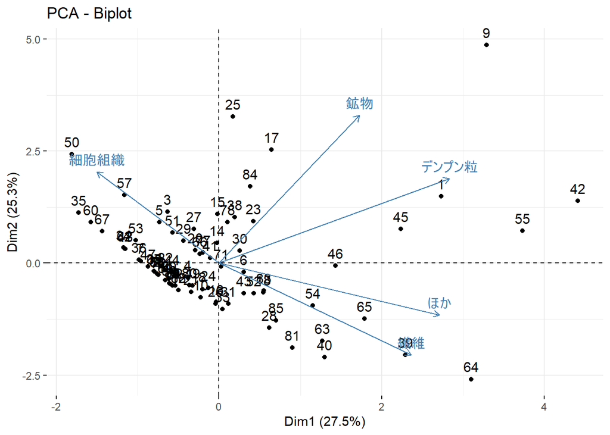

```r
# 主成分1と2を表示
fviz_pca_biplot(res.pca) # 主成分1と2を表示，axes = C(○,○))で別の主成分を表示可能
```

```r
ggsave(file = "Fig8.png", width = 6, height = 6, dpi = 300) # ファイルの保存
```

デンプン粒と鉱物は，同じ意味を持つ変数，すなわち填料である。細胞組織の断片，繊維とほか（他の物質）は異なる変数を示すため，素材由来の構成物だけの含有ではない。

# 料紙構成物の因子分析

料紙構成物に共通して影響する因子を仮定，この因子から変数間の相関関係を考える。

## 松尾大社社蔵史料

```r
# 因子分析を行うパッケージを読み込む
library(psych)
library(GPArotation)

tbs9<- read_csv("matsunoo-compo.csv")  # CSVファイルの読み取り
tbs9 # 読み込んだデータ
```

```
# A tibble: 63 x 7
   目録番号 紙素材 デンプン粒  鉱物 細胞組織  繊維  ほか
      <dbl> <chr>       <dbl> <dbl>    <dbl> <dbl> <dbl>
 1        1 コウゾ          0     0        0     0    41
 2        2 コウゾ          0     0      497     6    62
 3        3 コウゾ          2     6      263     0     0
 4        4 コウゾ          0     1      236     5     0
 5        5 コウゾ          0     0      207     6     0
 6        6 コウゾ          0     0      207     6     0
 7        7 コウゾ          0     0      348     9     0
 8        8 コウゾ          0     0      194     9     0
 9        9 コウゾ          0     0      326     8     0
10       10 宿紙           20     0       35     4     0
# ... with 53 more rows
```

```r
# 構成物の種類を実数型に変換
tbs10 <-
  tbs9 %>%
  filter(紙素材 %in% "コウゾ") %>%　　　 # コウゾだけを選択
  select(デンプン粒,鉱物,細胞組織,繊維,ほか) %>%
  mutate(
    デンプン粒 = as.numeric(デンプン粒), # デンプン粒を実数に変換
    鉱物 = as.numeric(鉱物),　　　　　　 # 鉱物を実数に変換
    細胞組織 = as.numeric(細胞組織),　　 # 細胞組織を実数に変換
    繊維 = as.numeric(繊維),　　　　　　 # 繊維を実数に変換
    ほか = as.numeric(ほか))　　　　　　 # ほか（他の物質）を実数に変換

# 構成物間の相関係数を出す
相関行列 <- cor(tbs10)
相関行列
```

```
            デンプン粒         鉱物    細胞組織       繊維         ほか
デンプン粒  1.00000000  0.178117057  0.04013211 -0.2260588  0.251047101
鉱物        0.17811706  1.000000000 -0.01007123 -0.1963919  0.006946198
細胞組織    0.04013211 -0.010071233  1.00000000  0.5646413 -0.019583962
繊維       -0.22605882 -0.196391894  0.56464126  1.0000000 -0.186244340
ほか        0.25104710  0.006946198 -0.01958396 -0.1862443  1.000000000
```

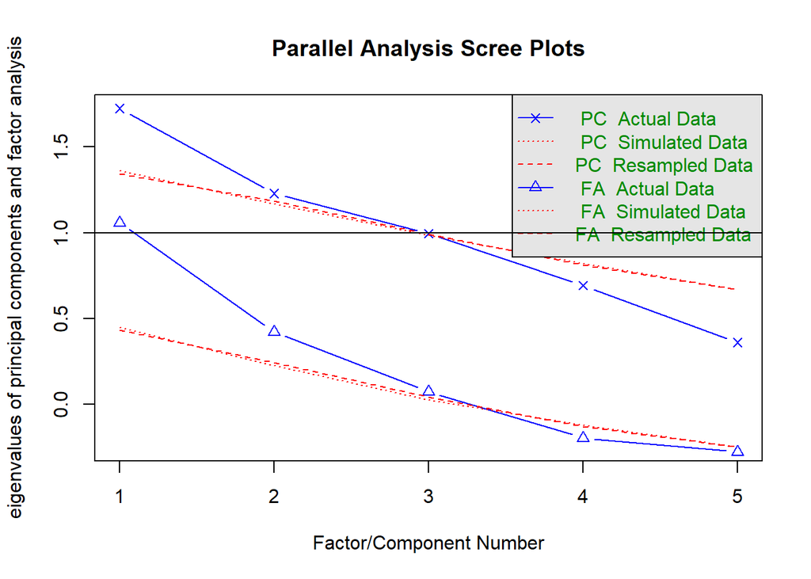

[output not shown]

```r
# 因子数を決める
fa.parallel(tbs10,SMC=TRUE) # スクリープロットを表示
```

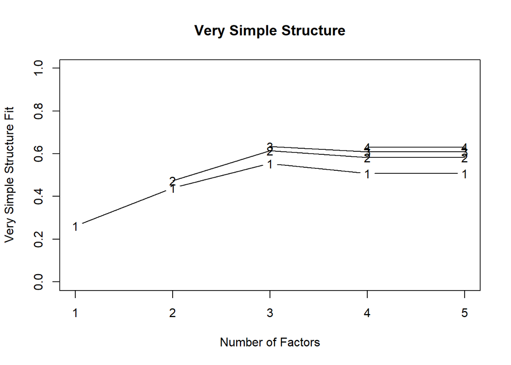

```
Very Simple Structure
Call: vss(x = tbs8, rotate = "varimax", n.obs = N)
VSS complexity 1 achieves a maximimum of 0.55  with  3  factors
VSS complexity 2 achieves a maximimum of 0.61  with  3  factors

The Velicer MAP achieves a minimum of NA  with  1  factors
BIC achieves a minimum of  NA  with  1  factors
Sample Size adjusted BIC achieves a minimum of  NA  with  2  factors

Statistics by number of factors
  vss1 vss2   map dof   chisq prob sqresid  fit RMSEA   BIC SABIC complex
1 0.26 0.00 0.086   5 9.1e+00  0.1     4.0 0.26 0.098 -13.1  2.68     1.0
2 0.44 0.47 0.179   1 1.1e+00  0.3     2.8 0.47 0.027  -3.4 -0.21     1.2
3 0.55 0.61 0.412  -2 2.1e-09   NA     2.0 0.63    NA    NA    NA     1.4
4 0.51 0.58 1.000  -4 0.0e+00   NA     2.0 0.63    NA    NA    NA     1.4
5 0.51 0.58    NA  -5 0.0e+00   NA     2.0 0.63    NA    NA    NA     1.4
   eChisq    SRMR eCRMS eBIC
1 1.7e+01 1.0e-01 0.141 -5.3
2 1.3e+00 2.8e-02 0.087 -3.1
3 3.3e-09 1.4e-06    NA   NA
4 1.7e-18 3.2e-11    NA   NA
5 1.7e-18 3.2e-11    NA   NA
```

```r
vss(tbs8, n.obs=N, rotate="varimax")
```